# 1. ОТЧЁТ МОДУЛЯ "A"

## 4.2 Разработка прикладного решения

После успешного создания модели машинного обучения. Нам нужно будет создать веб-сервер во Flask. Flask - это легкое веб-приложение, которое легко использовать и масштабировать до сложных приложений. В этом руководстве рассматривается базовая реализация приложения Flask, т.е. создание веб-сервера и простого REST API. Вот как организован весь проект:

Далее перейдём к написанию кода для app.py Ниже представлен код:

##### *С написанием копии кода возникла ошибка, поэтому показываю скриншоты написанного кода. Сами исходники можно увидеть в папке API*

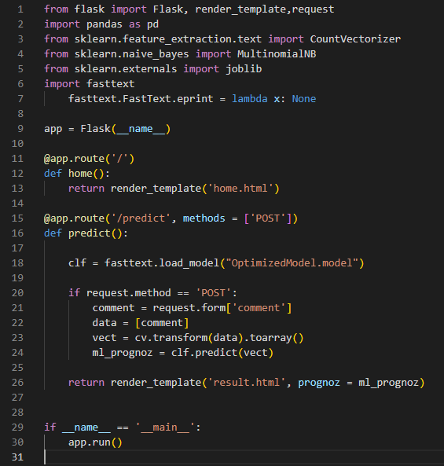

```python
from IPython.display import Image
display(Image(filename='C:/Users/Profi Main/Desktop/ОТЧЁТ МОДУЛЬ Г рабочее место 2 Конкурсант Сиотанов А_М/Data/Фото к отчёту/160445.png', width = 500)) # Локальный файл
```

После чего необходимо создать HTML домашнюю страницу, ниже приведён код:

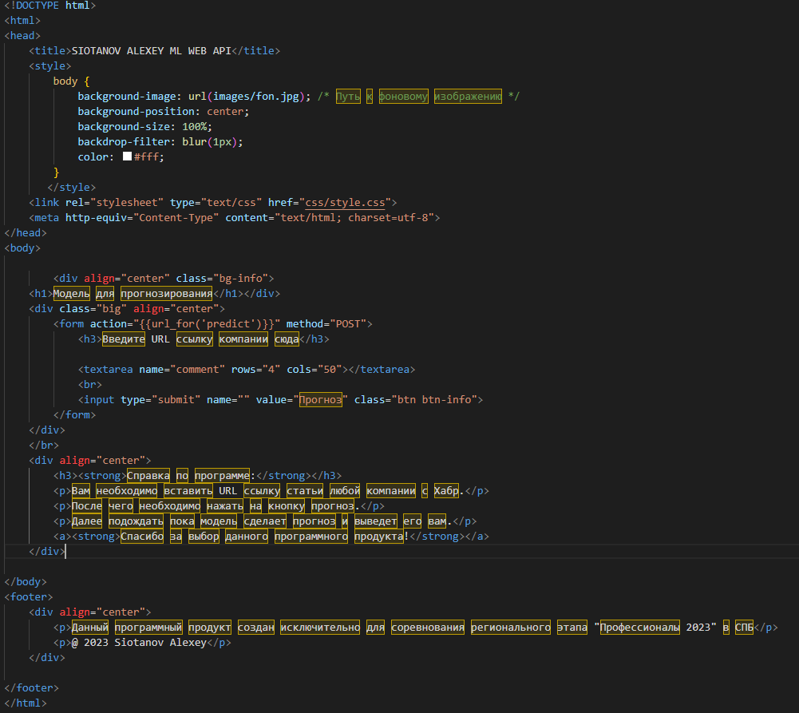

```python
display(Image(filename='C:/Users/Profi Main/Desktop/ОТЧЁТ МОДУЛЬ Г рабочее место 2 Конкурсант Сиотанов А_М/Data/Фото к отчёту/160400.png', width = 800)) # Локальный файл
```

Следующим этапом будет необходимость в страницу показа результата прогноза. СОздаём ещё одну страницу:

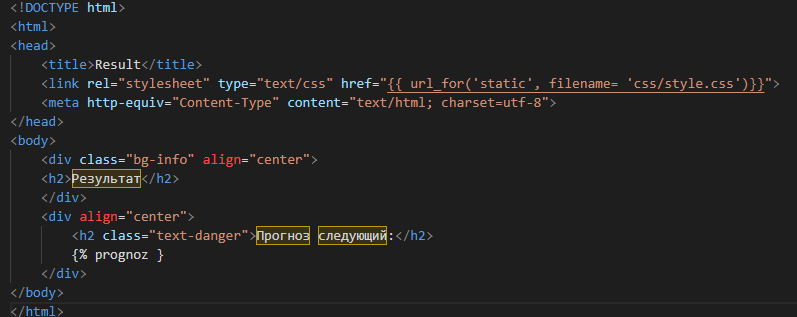

```python
display(Image(filename='C:/Users/Profi Main/Desktop/ОТЧЁТ МОДУЛЬ Г рабочее место 2 Конкурсант Сиотанов А_М/Data/Фото к отчёту/160120.png', width = 800)) # Локальный файл
```

После чего тестируем API: 1) Запускаем app.py командами:

```
- export FLASK_APP=app.py
- export FLASK_ENV=development
    - flask run
```

2) Далее переходим по ссылке http://127.0.0.1:500/ 3) Вписываем ссылку на статью с хабра о компании 4) Ждём некоторое время, после чего перекинет на другую станицу с результатами.

Пример домашней страницы

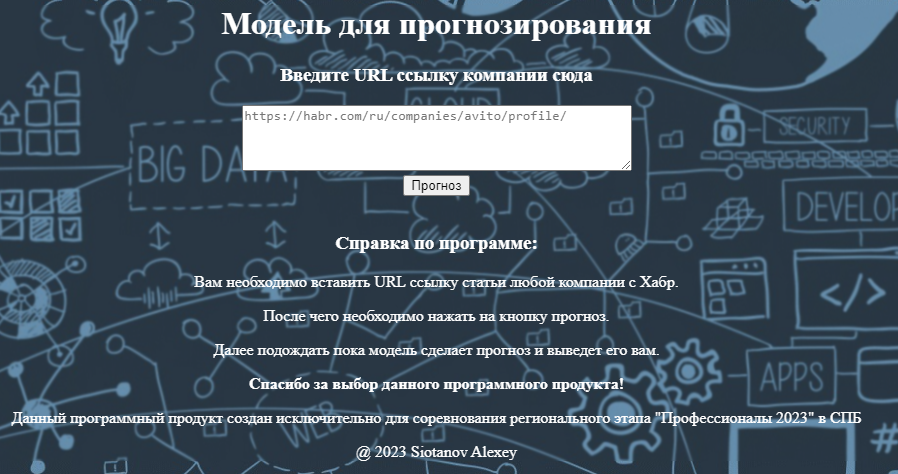

```python
display(Image(filename='C:/Users/Profi Main/Desktop/ОТЧЁТ МОДУЛЬ Г рабочее место 2 Конкурсант Сиотанов А_М/Data/Фото к отчёту/163724.png', width = 800)) # Локальный файл
```

Пример результата

[figure not shown]

```python
display(Image(filename='C:/Users/Profi Main/Desktop/ОТЧЁТ МОДУЛЬ Г рабочее место 2 Конкурсант Сиотанов А_М/Data/Фото к отчёту/163810.png', width = 800)) # Локальный файл
```